# Outline

### 1. Introduction

```
1.1. Introduction of Dataset
1.2. Description of Research Problem
1.3. Relevance of Research Problem
```

### 2. Import of Needed Libraries

```
2.1. Import of Python Libraries
2.2. Dataset Loading into python Dataframe
```

### 3. Data Wrangling

```
3.1. Data understanding
3.2. Data Dupliate check and Treatment
3.3. Missing values check and Handling it
```

### 4. Exploratory Data Analysis

```
4.1. Statistical Summary
4.2. EDA for Problem 1
4.3. EDA for Problem 2
4.4. EDA for problem 3
4.5. EDA for Problem 4
```

### 5. Conclusion

```
5.1. Communication of Results with respect to the Research questions
5.2. Final Comments
```

# 1. Introduction

This is my first project from the udacity-alx data analyst nanodegree scholarship. It is aimed at investigating datasets and deriving insights from them.

### 1.1. Introduction of Dataset

The dataset being explored in this project is the tmdb-movies dataset, with 21 columns. This data set contains information about 10,000 movies collected from The Movie Database (TMDb), including user ratings and revenue. The dataset contains several features which describes a movie. It is a collection of several movies, with unique and distinct features.

### 1.2. Description of Research Problem

This project is aimed at addressing the following questions;

```
1. Which movie has the highest number of vote_counts?
2. What is the spread of popularity of movies in the past few years?
3. Which production company generates the highest revenue with the least budgets?
4. Which features has more impact on revenue generated?
```

### 1.3. Relevance of Research Problem

The research problem is relevant, because it points towards understanding the datasets. And to further prepare the data for a predictive model with revenue being a target variable.

# 2. Import of Needed Libraries

### 2.1. Import of Python Libraries

The major libraries needed to complete this analysis are:

```
1. Pandas- For Data Manipulation
2. NumPy- For Numerical computations(if need be), and for handling data in arrays
3. Matplotlib - For visualizations and plots
4. Seaborn - For advance, beautiful and iterative visualizations
```

Other libraries may be imported as well, if there be need for that.

```python
import pandas as pd
import numpy as np
import matplotlib.pyplot as plt
import seaborn as sns
```

### 2.2. Dataset Loading into python Dataframe

```python
movie_df = pd.read_csv('tmdb-movies.csv')
movie_df.head()
```

|  | id | imdb_id | popularity | budget | revenue | original_title | cast | homepage | director | tagline | ... | overview | runtime | genres | production_companies | release_date | vote_count | vote_average | release_year | budget_adj | revenue_adj |
| --- | --- | --- | --- | --- | --- | --- | --- | --- | --- | --- | --- | --- | --- | --- | --- | --- | --- | --- | --- | --- | --- |
| 0 | 135397 | tt0369610 | 32.985763 | 150000000 | 1513528810 | Jurassic World | Chris Pratt\|Bryce Dallas Howard\|Irrfan Khan\|Vi... | http://www.jurassicworld.com/ | Colin Trevorrow | The park is open. | ... | Twenty-two years after the events of Jurassic ... | 124 | Action\|Adventure\|Science Fiction\|Thriller | Universal Studios\|Amblin Entertainment\|Legenda... | 6/9/15 | 5562 | 6.5 | 2015 | 1.379999e+08 | 1.392446e+09 |
| 1 | 76341 | tt1392190 | 28.419936 | 150000000 | 378436354 | Mad Max: Fury Road | Tom Hardy\|Charlize Theron\|Hugh Keays-Byrne\|Nic... | http://www.madmaxmovie.com/ | George Miller | What a Lovely Day. | ... | An apocalyptic story set in the furthest reach... | 120 | Action\|Adventure\|Science Fiction\|Thriller | Village Roadshow Pictures\|Kennedy Miller Produ... | 5/13/15 | 6185 | 7.1 | 2015 | 1.379999e+08 | 3.481613e+08 |
| 2 | 262500 | tt2908446 | 13.112507 | 110000000 | 295238201 | Insurgent | Shailene Woodley\|Theo James\|Kate Winslet\|Ansel... | http://www.thedivergentseries.movie/#insurgent | Robert Schwentke | One Choice Can Destroy You | ... | Beatrice Prior must confront her inner demons ... | 119 | Adventure\|Science Fiction\|Thriller | Summit Entertainment\|Mandeville Films\|Red Wago... | 3/18/15 | 2480 | 6.3 | 2015 | 1.012000e+08 | 2.716190e+08 |
| 3 | 140607 | tt2488496 | 11.173104 | 200000000 | 2068178225 | Star Wars: The Force Awakens | Harrison Ford\|Mark Hamill\|Carrie Fisher\|Adam D... | http://www.starwars.com/films/star-wars-episod... | J.J. Abrams | Every generation has a story. | ... | Thirty years after defeating the Galactic Empi... | 136 | Action\|Adventure\|Science Fiction\|Fantasy | Lucasfilm\|Truenorth Productions\|Bad Robot | 12/15/15 | 5292 | 7.5 | 2015 | 1.839999e+08 | 1.902723e+09 |
| 4 | 168259 | tt2820852 | 9.335014 | 190000000 | 1506249360 | Furious 7 | Vin Diesel\|Paul Walker\|Jason Statham\|Michelle ... | http://www.furious7.com/ | James Wan | Vengeance Hits Home | ... | Deckard Shaw seeks revenge against Dominic Tor... | 137 | Action\|Crime\|Thriller | Universal Pictures\|Original Film\|Media Rights ... | 4/1/15 | 2947 | 7.3 | 2015 | 1.747999e+08 | 1.385749e+09 |

5 rows × 21 columns

# 3. Data Wrangling

Here, there is data understanding, checking for issues that are associated with the dataset, and how best to handle this issues.

### 3.1. Data understanding

```python
# Let's see the shape of the movie dataset
movie_df.shape
```

```
(10866, 21)
```

```python
# Let's have an overview of the data
movie_df.info()
```

```
<class 'pandas.core.frame.DataFrame'>
RangeIndex: 10866 entries, 0 to 10865
Data columns (total 21 columns):
id                      10866 non-null int64
imdb_id                 10856 non-null object
popularity              10866 non-null float64
budget                  10866 non-null int64
revenue                 10866 non-null int64
original_title          10866 non-null object
cast                    10790 non-null object
homepage                2936 non-null object
director                10822 non-null object
tagline                 8042 non-null object
keywords                9373 non-null object
overview                10862 non-null object
runtime                 10866 non-null int64
genres                  10843 non-null object
production_companies    9836 non-null object
release_date            10866 non-null object
vote_count              10866 non-null int64
vote_average            10866 non-null float64
release_year            10866 non-null int64
budget_adj              10866 non-null float64
revenue_adj             10866 non-null float64
dtypes: float64(4), int64(6), object(11)
memory usage: 1.7+ MB
```

From the above, we realise that there are 10,866 rows and 21 columns in the dataset. The features comprise of three major datatypes.

- Integers
- Objects (Strings)
- Floats

### 3.2. Data Dupliates check and Treatment

```python
# Let's Check for duplicates in the dataset
movie_df.duplicated().any()
```

```
True
```

```python
# let's view the duplicated data
movie_df[movie_df.duplicated()]
```

|  | id | imdb_id | popularity | budget | revenue | original_title | cast | homepage | director | tagline | ... | overview | runtime | genres | production_companies | release_date | vote_count | vote_average | release_year | budget_adj | revenue_adj |
| --- | --- | --- | --- | --- | --- | --- | --- | --- | --- | --- | --- | --- | --- | --- | --- | --- | --- | --- | --- | --- | --- |
| 2090 | 42194 | tt0411951 | 0.59643 | 30000000 | 967000 | TEKKEN | Jon Foo\|Kelly Overton\|Cary-Hiroyuki Tagawa\|Ian... | NaN | Dwight H. Little | Survival is no game | ... | In the year of 2039, after World Wars destroy ... | 92 | Crime\|Drama\|Action\|Thriller\|Science Fiction | Namco\|Light Song Films | 3/20/10 | 110 | 5.0 | 2010 | 30000000.0 | 967000.0 |

1 rows × 21 columns

From the code cell above, there is a duplicate in the dataset. Entry 2090 is a duplicate, thus, should be dropped.

```python
# Let's drop the duplicate
movie_df.drop_duplicates(inplace=True)
```

```python
# Let's confirm the duplicates have been dropped
movie_df.duplicated().any()
```

```
False
```

The duplicate has been dropped.

### 3.3. Missing values check and Handling it

```python
# Let's check for missing values
movie_df.isna().sum()
```

```
id                         0
imdb_id                   10
popularity                 0
budget                     0
revenue                    0
original_title             0
cast                      76
homepage                7929
director                  44
tagline                 2824
keywords                1493
overview                   4
runtime                    0
genres                    23
production_companies    1030
release_date               0
vote_count                 0
vote_average               0
release_year               0
budget_adj                 0
revenue_adj                0
dtype: int64
```

```python
movie_df.info()
```

```
<class 'pandas.core.frame.DataFrame'>
Int64Index: 10865 entries, 0 to 10865
Data columns (total 21 columns):
id                      10865 non-null int64
imdb_id                 10855 non-null object
popularity              10865 non-null float64
budget                  10865 non-null int64
revenue                 10865 non-null int64
original_title          10865 non-null object
cast                    10789 non-null object
homepage                2936 non-null object
director                10821 non-null object
tagline                 8041 non-null object
keywords                9372 non-null object
overview                10861 non-null object
runtime                 10865 non-null int64
genres                  10842 non-null object
production_companies    9835 non-null object
release_date            10865 non-null object
vote_count              10865 non-null int64
vote_average            10865 non-null float64
release_year            10865 non-null int64
budget_adj              10865 non-null float64
revenue_adj             10865 non-null float64
dtypes: float64(4), int64(6), object(11)
memory usage: 1.8+ MB
```

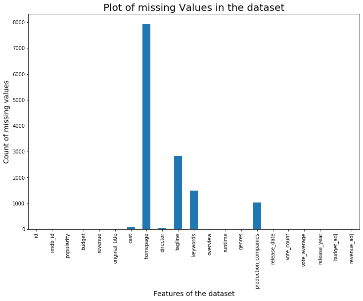

```python
# Let's visualize to see the missing vales in the dataset
plt.figure(figsize=(12, 8))
movie_df.isna().sum().plot(kind='bar')
plt.title('Plot of missing Values in the dataset', fontsize=20)
plt.xlabel('Features of the dataset', fontsize=14)
plt.ylabel('Count of missing values', fontsize=14);
```

There are missing values in the dataset, thus should be handled. There are different ways of handling missing values in a dataset. They include;

```
1. Filling missing values with statistical parameters like; mean, median, and mode.
2. Filling missing values with forward and backward fill.
3. Using the Interpolation method.
```

For the this project, I will apply two methods filling the missing values.

- For columns with integer datatype, the missing values are filled using the mean of the column.
- For columns with string datatype with small amount of missing values, the mode will be used to fill the missing values.
- For Columns with string datatype but large amount of missing values, the forward and backward fill method will be used.

```python
movie_df.isna().sum()
```

```
id                         0
imdb_id                   10
popularity                 0
budget                     0
revenue                    0
original_title             0
cast                      76
homepage                7929
director                  44
tagline                 2824
keywords                1493
overview                   4
runtime                    0
genres                    23
production_companies    1030
release_date               0
vote_count                 0
vote_average               0
release_year               0
budget_adj                 0
revenue_adj                0
dtype: int64
```

```python
# Filling columns with strings and small missing values with mode
def fill_with_mode(dataset, column):
    col_mode = dataset[column].mode
    return dataset[column].fillna(col_mode, inplace=True)
```

The function, fill_with_mode will be used to handle the following columns

```python
fill_with_mode(movie_df, 'imdb_id') # Filling imdb_id column
fill_with_mode(movie_df, 'cast') # Filling cast column
fill_with_mode(movie_df, 'overview') # Filling overview column
fill_with_mode(movie_df, 'director') # Filling director column
fill_with_mode(movie_df, 'genres') # Filling genres column
```

```python
# Filling columns with string datatype with large amount of missing values.
def forward_back_fill(dataset, column):
    return movie_df[column].fillna(method='ffill', inplace=True), movie_df[column].fillna(method='bfill', inplace=True)
```

The forward, backward fill method will be used to fill the following columns;

- homepage
- tagline
- keywords
- production_companies

```python
# Applying the forward and backward fill method
forward_back_fill(movie_df, 'homepage')
forward_back_fill(movie_df, 'tagline')
forward_back_fill(movie_df, 'keywords')
forward_back_fill(movie_df, 'production_companies')
```

```
(None, None)
```

```python
# Let's confirm the missing values have been handled
movie_df.isna().sum()
```

```
id                      0
imdb_id                 0
popularity              0
budget                  0
revenue                 0
original_title          0
cast                    0
homepage                0
director                0
tagline                 0
keywords                0
overview                0
runtime                 0
genres                  0
production_companies    0
release_date            0
vote_count              0
vote_average            0
release_year            0
budget_adj              0
revenue_adj             0
dtype: int64
```

The missing values have been handled.

# 4. Exploratory Data Analysis

Here, the statistical summary of the dataset will be determined. Various analysis with respect to the research problem will be done. The uniriate analysis, bivariate and multivariate analysis, will be handled here.

### 4.1. Statistical Summary

The statistical summary of each feature of the dataset will be obtained here.

```python
# The describe function is used for the statistical summmary
movie_df.describe()
```

|  | id | popularity | budget | revenue | runtime | vote_count | vote_average | release_year | budget_adj | revenue_adj |
| --- | --- | --- | --- | --- | --- | --- | --- | --- | --- | --- |
| count | 10865.000000 | 10865.000000 | 1.086500e+04 | 1.086500e+04 | 10865.000000 | 10865.000000 | 10865.000000 | 10865.000000 | 1.086500e+04 | 1.086500e+04 |
| mean | 66066.374413 | 0.646446 | 1.462429e+07 | 3.982690e+07 | 102.071790 | 217.399632 | 5.975012 | 2001.321859 | 1.754989e+07 | 5.136900e+07 |
| std | 92134.091971 | 1.000231 | 3.091428e+07 | 1.170083e+08 | 31.382701 | 575.644627 | 0.935138 | 12.813260 | 3.430753e+07 | 1.446383e+08 |
| min | 5.000000 | 0.000065 | 0.000000e+00 | 0.000000e+00 | 0.000000 | 10.000000 | 1.500000 | 1960.000000 | 0.000000e+00 | 0.000000e+00 |
| 25% | 10596.000000 | 0.207575 | 0.000000e+00 | 0.000000e+00 | 90.000000 | 17.000000 | 5.400000 | 1995.000000 | 0.000000e+00 | 0.000000e+00 |
| 50% | 20662.000000 | 0.383831 | 0.000000e+00 | 0.000000e+00 | 99.000000 | 38.000000 | 6.000000 | 2006.000000 | 0.000000e+00 | 0.000000e+00 |
| 75% | 75612.000000 | 0.713857 | 1.500000e+07 | 2.400000e+07 | 111.000000 | 146.000000 | 6.600000 | 2011.000000 | 2.085325e+07 | 3.370173e+07 |
| max | 417859.000000 | 32.985763 | 4.250000e+08 | 2.781506e+09 | 900.000000 | 9767.000000 | 9.200000 | 2015.000000 | 4.250000e+08 | 2.827124e+09 |

### 4.2. EDA for Problem 1

#### The Problem 1: Which movie has the highest number of vote_counts?

```python
movie_df['original_title'].head()
```

```
0                  Jurassic World
1              Mad Max: Fury Road
2                       Insurgent
3    Star Wars: The Force Awakens
4                       Furious 7
Name: original_title, dtype: object
```

```python
movie_df.columns
```

```
Index(['id', 'imdb_id', 'popularity', 'budget', 'revenue', 'original_title',
       'cast', 'homepage', 'director', 'tagline', 'keywords', 'overview',
       'runtime', 'genres', 'production_companies', 'release_date',
       'vote_count', 'vote_average', 'release_year', 'budget_adj',
       'revenue_adj'],
      dtype='object')
```

```python
movie = movie_df[['original_title', 'vote_count']]
```

```python
movie.head()
```

|  | original_title | vote_count |
| --- | --- | --- |
| 0 | Jurassic World | 5562 |
| 1 | Mad Max: Fury Road | 6185 |
| 2 | Insurgent | 2480 |
| 3 | Star Wars: The Force Awakens | 5292 |
| 4 | Furious 7 | 2947 |

```python
high_vote_movie = movie.query('vote_count >= 7000')
```

```python
high_vote_movie.head()
```

|  | original_title | vote_count |
| --- | --- | --- |
| 1386 | Avatar | 8458 |
| 1919 | Inception | 9767 |
| 2875 | The Dark Knight | 8432 |
| 4361 | The Avengers | 8903 |
| 4364 | Django Unchained | 7375 |

```python
high_vote_movie.info()
```

```
<class 'pandas.core.frame.DataFrame'>
Int64Index: 6 entries, 1386 to 4382
Data columns (total 2 columns):
original_title    6 non-null object
vote_count        6 non-null int64
dtypes: int64(1), object(1)
memory usage: 144.0+ bytes
```

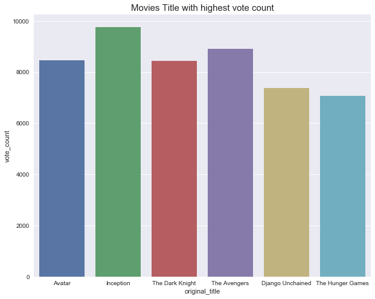

```python
plt.figure(figsize=(10, 8))
plt.style.use('seaborn')
sns.barplot(data=high_vote_movie, x="original_title", y="vote_count")
plt.title('Movies Title with highest vote count', fontsize=15);
```

From the plot the movie 'Inception' has the highest vote count.

### 2. What is the spread of popularity of movies in the past few years?

```python
movie_df.columns
```

```
Index(['id', 'imdb_id', 'popularity', 'budget', 'revenue', 'original_title',
       'cast', 'homepage', 'director', 'tagline', 'keywords', 'overview',
       'runtime', 'genres', 'production_companies', 'release_date',
       'vote_count', 'vote_average', 'release_year', 'budget_adj',
       'revenue_adj'],
      dtype='object')
```

```python
# Let's analysis the three columns, original_title, popularity, & release_year
popular_movie = movie_df[['original_title', 'popularity', 'release_year']]
popular_movie.head()
```

|  | original_title | popularity | release_year |
| --- | --- | --- | --- |
| 0 | Jurassic World | 32.985763 | 2015 |
| 1 | Mad Max: Fury Road | 28.419936 | 2015 |
| 2 | Insurgent | 13.112507 | 2015 |
| 3 | Star Wars: The Force Awakens | 11.173104 | 2015 |
| 4 | Furious 7 | 9.335014 | 2015 |

```python
# let's query the dataset to have the most recent movies. So the movie dataset for 2010 above have been selected.
recent_movies = popular_movie.query('release_year >= 2010')
```

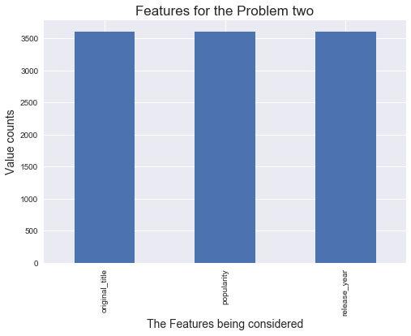

```python
recent_movies.count().plot(kind='bar')
plt.xlabel('The Features being considered', fontsize=14)
plt.ylabel('Value counts', fontsize=14)
plt.title('Features for the Problem two', fontsize=17);
```

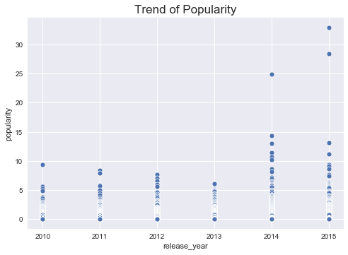

```python
# lets examine the relationship between popularity and release_year
sns.scatterplot(x='release_year', y='popularity', data=recent_movies)
plt.title('Trend of Popularity', fontsize=17);
```

```python
# lets take a closer look at the most recent movie released, i.e. 2015
recent_movies = recent_movies.query('release_year == 2015')
recent_movies.head()
```

|  | original_title | popularity | release_year |
| --- | --- | --- | --- |
| 0 | Jurassic World | 32.985763 | 2015 |
| 1 | Mad Max: Fury Road | 28.419936 | 2015 |
| 2 | Insurgent | 13.112507 | 2015 |
| 3 | Star Wars: The Force Awakens | 11.173104 | 2015 |
| 4 | Furious 7 | 9.335014 | 2015 |

```python
recent_movies.tail()
```

|  | original_title | popularity | release_year |
| --- | --- | --- | --- |
| 624 | Once I Was a Beehive | 0.017625 | 2015 |
| 625 | John Mulaney: The Comeback Kid | 0.017050 | 2015 |
| 626 | Meet the Patels | 0.014647 | 2015 |
| 627 | I Hate Christian Laettner | 0.030371 | 2015 |
| 628 | The Emperor's New Clothes | 0.003920 | 2015 |

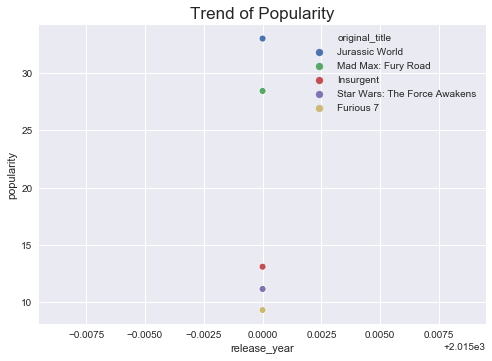

```python
# lets examine the relationship between popularity and release_year
sns.scatterplot(x='release_year', y='popularity', data=recent_movies.iloc[0:5], hue='original_title')
plt.title('Trend of Popularity', fontsize=17);
```

From the plot, it is been realized that the most popular movie in 2015 is 'Jurassic World'

### 3. Which production company generates the highest revenue with the least budgets?

Here, we want to answer the question which company has the highest revenue with least budget?

```python
movie_df.columns
```

```
Index(['id', 'imdb_id', 'popularity', 'budget', 'revenue', 'original_title',
       'cast', 'homepage', 'director', 'tagline', 'keywords', 'overview',
       'runtime', 'genres', 'production_companies', 'release_date',
       'vote_count', 'vote_average', 'release_year', 'budget_adj',
       'revenue_adj'],
      dtype='object')
```

```python
movie_revenue = movie_df[['budget', 'revenue', 'production_companies', 'budget_adj', 'revenue_adj']]
movie_revenue.head()
```

|  | budget | revenue | production_companies | budget_adj | revenue_adj |
| --- | --- | --- | --- | --- | --- |
| 0 | 150000000 | 1513528810 | Universal Studios\|Amblin Entertainment\|Legenda... | 1.379999e+08 | 1.392446e+09 |
| 1 | 150000000 | 378436354 | Village Roadshow Pictures\|Kennedy Miller Produ... | 1.379999e+08 | 3.481613e+08 |
| 2 | 110000000 | 295238201 | Summit Entertainment\|Mandeville Films\|Red Wago... | 1.012000e+08 | 2.716190e+08 |
| 3 | 200000000 | 2068178225 | Lucasfilm\|Truenorth Productions\|Bad Robot | 1.839999e+08 | 1.902723e+09 |
| 4 | 190000000 | 1506249360 | Universal Pictures\|Original Film\|Media Rights ... | 1.747999e+08 | 1.385749e+09 |

In order to get the company that have the highest revenue with the least budget, let's subtract the budget from the revenue. Let's call that the income. We do that both for the actual and the adjusted.

```python
def income(df, col1, col2):
    return df[col2] - df[col1]
```

```python
movie_revenue['income'] = income(movie_revenue, 'budget', 'revenue');
movie_revenue['income_adj'] = income(movie_revenue, 'budget_adj', 'revenue_adj');
```

```python
movie_revenue.head()
```

|  | budget | revenue | production_companies | budget_adj | revenue_adj | income | income_adj |
| --- | --- | --- | --- | --- | --- | --- | --- |
| 0 | 150000000 | 1513528810 | Universal Studios\|Amblin Entertainment\|Legenda... | 1.379999e+08 | 1.392446e+09 | 1363528810 | 1.254446e+09 |
| 1 | 150000000 | 378436354 | Village Roadshow Pictures\|Kennedy Miller Produ... | 1.379999e+08 | 3.481613e+08 | 228436354 | 2.101614e+08 |
| 2 | 110000000 | 295238201 | Summit Entertainment\|Mandeville Films\|Red Wago... | 1.012000e+08 | 2.716190e+08 | 185238201 | 1.704191e+08 |
| 3 | 200000000 | 2068178225 | Lucasfilm\|Truenorth Productions\|Bad Robot | 1.839999e+08 | 1.902723e+09 | 1868178225 | 1.718723e+09 |
| 4 | 190000000 | 1506249360 | Universal Pictures\|Original Film\|Media Rights ... | 1.747999e+08 | 1.385749e+09 | 1316249360 | 1.210949e+09 |

Since we have the income columns, let's drop the budgets and the revenue columns.

```python
movie_revenue = movie_revenue.drop(columns=['budget', 'revenue', 'budget_adj', 'revenue_adj'])
movie_revenue.head()
```

|  | production_companies | income | income_adj |
| --- | --- | --- | --- |
| 0 | Universal Studios\|Amblin Entertainment\|Legenda... | 1363528810 | 1.254446e+09 |
| 1 | Village Roadshow Pictures\|Kennedy Miller Produ... | 228436354 | 2.101614e+08 |
| 2 | Summit Entertainment\|Mandeville Films\|Red Wago... | 185238201 | 1.704191e+08 |
| 3 | Lucasfilm\|Truenorth Productions\|Bad Robot | 1868178225 | 1.718723e+09 |
| 4 | Universal Pictures\|Original Film\|Media Rights ... | 1316249360 | 1.210949e+09 |

```python
movie_revenue.describe()
```

|  | income | income_adj |
| --- | --- | --- |
| count | 1.086500e+04 | 1.086500e+04 |
| mean | 2.520261e+07 | 3.381911e+07 |
| std | 9.659103e+07 | 1.252194e+08 |
| min | -4.139124e+08 | -4.139124e+08 |
| 25% | 0.000000e+00 | 0.000000e+00 |
| 50% | 0.000000e+00 | 0.000000e+00 |
| 75% | 9.092453e+06 | 1.293091e+07 |
| max | 2.544506e+09 | 2.750137e+09 |

```python
movie_revenue['income'].max()
```

```
2544505847
```

```python
movie_revenue['income_adj'].max()
```

```
2750136650.919176
```

```python
highest_revenue = movie_revenue[movie_revenue['income']>=2544505847]
```

```python
highest_revenue2015 = movie_revenue[movie_revenue['income_adj']>=2750136650.919176]
```

```python
print('The Company with the highest revenue before the price inflation in 2015 is; {}'.format(highest_revenue['production_companies']))
print()
print('The Company with the highest revenue after the price inflation in 2015 is; {}'.format(highest_revenue2015['production_companies']))
```

```
The Company with the highest revenue before the price inflation in 2015 is; 1386    Ingenious Film Partners|Twentieth Century Fox ...
Name: production_companies, dtype: object

The Company with the highest revenue after the price inflation in 2015 is; 1329    Lucasfilm|Twentieth Century Fox Film Corporation
Name: production_companies, dtype: object
```

1. Ingenious Film Partners|Twentieth Century Fox is the company with the highest revenue before the 2015 inflation
2. Lucasfilm|Twentieth Century Fox Film Corporation is the company with the highest revenue after the 2015 inflation

### 4. Which features has more impact on revenue generated?

Let's see which feature will be correlated to the revenue

```python
movie_df.head()
```

|  | id | imdb_id | popularity | budget | revenue | original_title | cast | homepage | director | tagline | ... | overview | runtime | genres | production_companies | release_date | vote_count | vote_average | release_year | budget_adj | revenue_adj |
| --- | --- | --- | --- | --- | --- | --- | --- | --- | --- | --- | --- | --- | --- | --- | --- | --- | --- | --- | --- | --- | --- |
| 0 | 135397 | tt0369610 | 32.985763 | 150000000 | 1513528810 | Jurassic World | Chris Pratt\|Bryce Dallas Howard\|Irrfan Khan\|Vi... | http://www.jurassicworld.com/ | Colin Trevorrow | The park is open. | ... | Twenty-two years after the events of Jurassic ... | 124 | Action\|Adventure\|Science Fiction\|Thriller | Universal Studios\|Amblin Entertainment\|Legenda... | 6/9/15 | 5562 | 6.5 | 2015 | 1.379999e+08 | 1.392446e+09 |
| 1 | 76341 | tt1392190 | 28.419936 | 150000000 | 378436354 | Mad Max: Fury Road | Tom Hardy\|Charlize Theron\|Hugh Keays-Byrne\|Nic... | http://www.madmaxmovie.com/ | George Miller | What a Lovely Day. | ... | An apocalyptic story set in the furthest reach... | 120 | Action\|Adventure\|Science Fiction\|Thriller | Village Roadshow Pictures\|Kennedy Miller Produ... | 5/13/15 | 6185 | 7.1 | 2015 | 1.379999e+08 | 3.481613e+08 |
| 2 | 262500 | tt2908446 | 13.112507 | 110000000 | 295238201 | Insurgent | Shailene Woodley\|Theo James\|Kate Winslet\|Ansel... | http://www.thedivergentseries.movie/#insurgent | Robert Schwentke | One Choice Can Destroy You | ... | Beatrice Prior must confront her inner demons ... | 119 | Adventure\|Science Fiction\|Thriller | Summit Entertainment\|Mandeville Films\|Red Wago... | 3/18/15 | 2480 | 6.3 | 2015 | 1.012000e+08 | 2.716190e+08 |
| 3 | 140607 | tt2488496 | 11.173104 | 200000000 | 2068178225 | Star Wars: The Force Awakens | Harrison Ford\|Mark Hamill\|Carrie Fisher\|Adam D... | http://www.starwars.com/films/star-wars-episod... | J.J. Abrams | Every generation has a story. | ... | Thirty years after defeating the Galactic Empi... | 136 | Action\|Adventure\|Science Fiction\|Fantasy | Lucasfilm\|Truenorth Productions\|Bad Robot | 12/15/15 | 5292 | 7.5 | 2015 | 1.839999e+08 | 1.902723e+09 |
| 4 | 168259 | tt2820852 | 9.335014 | 190000000 | 1506249360 | Furious 7 | Vin Diesel\|Paul Walker\|Jason Statham\|Michelle ... | http://www.furious7.com/ | James Wan | Vengeance Hits Home | ... | Deckard Shaw seeks revenge against Dominic Tor... | 137 | Action\|Crime\|Thriller | Universal Pictures\|Original Film\|Media Rights ... | 4/1/15 | 2947 | 7.3 | 2015 | 1.747999e+08 | 1.385749e+09 |

5 rows × 21 columns

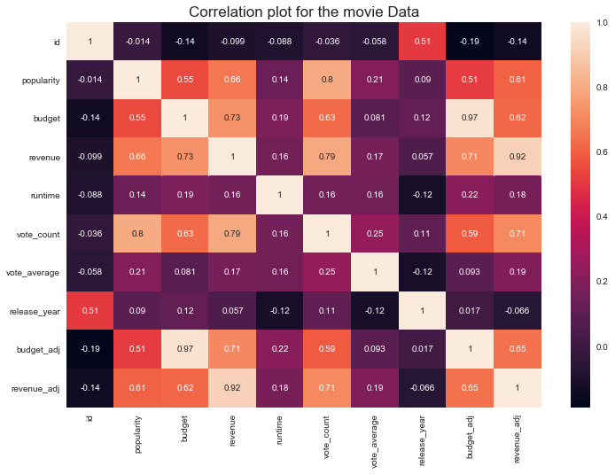

```python
# Let's use the correlation plot for this.
plt.figure(figsize=(12, 8))
sns.heatmap(movie_df.corr(), annot=True)
plt.title('Correlation plot for the movie Data', fontsize=17);
```

# 5. Conclusion¶

### 5.1. Communication of Results with respect to the Research questions

1. Which movie has the highest number of vote_counts?
2. What is the spread of popularity of movies in the past few years?
3. Which production company generates the highest revenue with the least budgets?
4. Which features has more impact on revenue generated?

These gives an insight to how much revenue could be generated.

### 5.2. Final Comments

Taking revenue as a target variable a model build, the vote_count feature will have the highest impact on the revenue being generated. Although, there could be further analysis.